# DS1 Final Project

## Product College 2018 Applicants Data

Miki Nomura

# Data Basics

- **1226** Applications Data for Fall 2018
- Exported from **Hubspot** - one of the popular CRM (Customer Relationship Management) tools.
- Out of 1226, **234** were admitted
- Out of 234, **91** checked in on the day 1 of the program

Features:

1. Demographics (Gender, Location, Age etc)
2. Marketing Data (Email Open Rates, Website Visits, Where they come from etc)
3. Application Data (Character Counts, Coding Level, Current Applicant Stage (Pending Admissions Decision, Admitted etc))

**381** features in total (too many..)

# Objective

## Recruit more students!

### First, we want to understand where we're now.

To get more students for Fall 2019, we've been doing a lot of initiatives, and we started getting applications. But, it takes time to know how many will be actually admitted, and how many will come to the program. So, as the Growht Lead, I want to know:

- When we get applications: Out of the total applications, how many applicants looks qualified to be admitted? (or how many doesn't look qualified.
- When we admit students: How many admits will actually show up in the day 1?

# Questions

- What features make the difference between applicants and admits?
- What features make the difference between admits and attendees?

# Insights

1. **Character counts** are different between admits and non-admits, but *not* between attendees and non-attendees.
2. There is *no* difference in **Email Open Counts and Click Counts** between attendees and non-attendees.
3. There is a difference in **Website Visits and Page Views** between attendees and non-attendees.

## Methods

- Histograms
- T Tests

# Key Feature 1: Character Count

```
Text(0.5,1,'Character Count of Non-Admits')
```

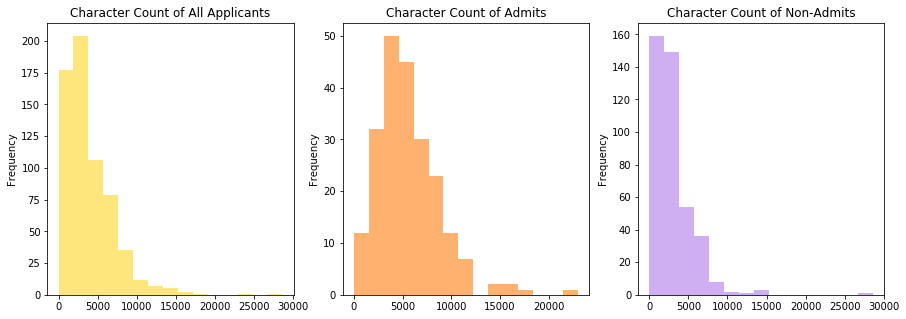

```python
# Histgram of character count for all applicants
fig, axs = plt.subplots(1,3,figsize=(15,5))
df_admit = df[df["Year 2018 Applications Admitted"].str.contains("Product College")]
df_nonadmit = df[~df["Year 2018 Applications Admitted"].str.contains("Product College")]

df["PC Character Count_y"].plot.hist(bins=15, ax=axs[0], color="#ffe67c").set_title("Character Count of All Applicants")
df_admit["PC Character Count_y"].plot.hist(bins=15, ax=axs[1], color="#ffb16f").set_title("Character Count of Admits")
df_nonadmit["PC Character Count_y"].plot.hist(bins=15, ax=axs[2], color="#cfaef2").set_title("Character Count of Non-Admits")
```

Visually different, but is it true?

## T test!

```python
# One Sided Two Sample T Test: Admitted Group and Non-Admitted Group have difference in character count?
# Independent (unpaird) two-sample location test with a null hypothesis that
# the means of the two samples are equal (equal variance assued).

# H0: x̄1 = x̄2, or x̄2 - x̄1 = 0, No difference between two groups
# H1: There's a difference
# α = 0.05

import scipy.stats as stats

x1 = df_admit["PC Character Count_y"]
x2 = df_nonadmit["PC Character Count_y"]
alpha = 0.05

t, p_twosided = stats.ttest_ind(x2.dropna(), x1.dropna(), equal_var=True)
p_onesided = p_twosided / 2

print("P value (One sided): " + str(p_onesided) + ", T value: " + str(t))

if (p_onesided < alpha and t > 0):
    print("Reject Null Hypothesis: There's a difference between two groups and admits has less character counts")
elif (p_onesided < alpha and t < 0):
    print("Reject Null Hypothesis: There's a difference between two groups and admits has more character counts")
else:
    print("Accept Null Hypothesis: There's no difference between two groups")
```

```
P value (One sided): 4.645097885351169e-26 T value: -10.975003467810351
Reject Null Hypothesis: There's a difference between two groups and admits has more character counts
```

*P value (One sided): 4.645097885351169e-26 T value: -10.975003467810351*  
*Reject Null Hypothesis: There's a difference between two groups and admits has more character counts*

**Character count shows the difference between non-admits and admits.**

**How about admits vs attendees?**

```python
# Two Sample T test 2: Attending Group and non-attending group
# H0: x̄1 = x̄2, or x̄2 - x̄1 = 0, No difference between two groups
# H1: There's a difference
# α = 0.05

df_attending = df_admit[df_admit["2018 PC Checked-In"] == "Yes"]
df_non_attending = df_admit[df_admit["2018 PC Checked-In"] != "Yes"]

x1 = df_attending["PC Character Count_y"]
x2 = df_non_attending["PC Character Count_y"]
alpha = 0.05

t, p_twosided = stats.ttest_ind(x2.dropna(), x1.dropna(), equal_var=True)

print("P Value (Two Sided):" + str(p_twosided))

if p_twosided < alpha:
    print("Reject Null Hypothesis: There's a difference between two groups ")
else:
    print("Accept Null Hypothesis: There's no difference between two groups")
```

```
P Value (Two Sided):0.26050778614709325
Accept Null Hypothesis: There's no difference between two groups
```

**There's no difference between two groups (attendees and non-attendees)**

It's not going to help us measure the likelihood to attend..

# Conclusion 1: Character counts help us understand qualified applications, but not the likelihood to attend

# Key Feature 2: Email Opens / Clicks

```python
x1 = df_attending["Emails Opened"]
x2 = df_non_attending["Emails Opened"]
alpha = 0.05

t, p_twosided = stats.ttest_ind(x2.dropna(), x1.dropna(), equal_var=True)

if p_twosided < alpha:
    print("Reject Null Hypothesis: There's a difference between two groups ")
else:
    print("Accept Null Hypothesis: There's no difference between two groups")
```

```
Accept Null Hypothesis: There's no difference between two groups
```

```python
x1 = df_attending["Emails Clicked"]
x2 = df_non_attending["Emails Clicked"]

t, p_twosided = stats.ttest_ind(x2.dropna(), x1.dropna(), equal_var=True)

if p_twosided < alpha:
    print("Reject Null Hypothesis: There's a difference between two groups ")
else:
    print("Accept Null Hypothesis: There's no difference between two groups")
```

```
Accept Null Hypothesis: There's no difference between two groups
```

# Conclution 2: Emails are not telling us whether they will attend or not..

# Key Feature 3: Pageviews and Visits

```python
## Number of Pageviews

x1 = df_attending["Number of Pageviews_y"]
x2 = df_non_attending["Number of Pageviews_y"]

t, p_twosided = stats.ttest_ind(x2.dropna(), x1.dropna(), equal_var=True)

p_onesided = p_twosided / 2

if (p_onesided < alpha and t > 0):
    print("Reject Null Hypothesis: There's a difference between two groups and admits has less page views")
elif (p_onesided < alpha and t < 0):
    print("Reject Null Hypothesis: There's a difference between two groups and admits has more page views")
else:
    print("Accept Null Hypothesis: There's no difference between two groups")

print("P Value: " + str(p_twosided) + ", T:" + str(t))
```

```
Reject Null Hypothesis: There's a difference between two groups and admits has more page views
P Value: 1.3114882019395282e-07, T:-5.4595186576950665
```

```python
## Number of Visits
x1 = df_attending["Number of Visits"]
x2 = df_non_attending["Number of Visits"]

t, p_twosided = stats.ttest_ind(x2.dropna(), x1.dropna(), equal_var=True)
p_onesided = p_twosided / 2

if (p_onesided < alpha and t > 0):
    print("Reject Null Hypothesis: There's a difference between two groups and admits has less visits")
elif (p_onesided < alpha and t < 0):
    print("Reject Null Hypothesis: There's a difference between two groups and admits has more visite")
else:
    print("Accept Null Hypothesis: There's no difference between two groups")

print("P Value: " + str(p_onesided) + ", T:" + str(t))
```

```
Reject Null Hypothesis: There's a difference between two groups and admits has more visite
P Value: 1.1965656494351198e-15, T:-8.495809008174783
```

```
Text(0.5,1,'Pageviews (Non-Attendees)')
```

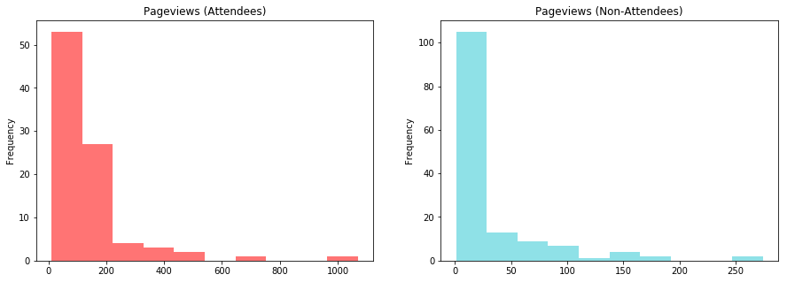

```python
fig, axs = plt.subplots(1,2,figsize=(15,5))

x1.plot.hist(ax=axs[0], color="#ff7474").set_title("Pageviews (Attendees)")
x2.plot.hist(ax=axs[1], color="#8fe1e7").set_title("Pageviews (Non-Attendees)")
```

# Conclusions

- **Character counts** helped us qualify applications but not likelihood to attend
- **Email open rate and click rate** *didn't* show difference between attendeed and non-attendees
- There are significant difference in **Website visit and page view**

# Next Steps

- Use the indicators for Fall 2019
- Find other features which tell us difference between applicants and admits, and attendees

# Special Thanks!

**Fang**: Worked with me during the weekend and taught me math, gave me feedback on my presentation  
**Jonathan**: Worked with me during the weekend

[figure not shown]

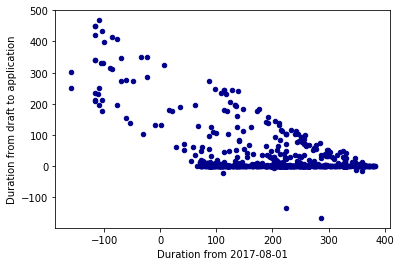

```python
## Plots - Relashons between when they submitted and when they started application
ax1 = df.plot.scatter(x='Duration from 2017-08-01', y='Duration from draft to application',c='DarkBlue')
```